# Chapter 2 Time Series Graphics

## Google stock price

```r
google_2015 |>
  ACF(Close, lag_max=100)
```

```
# A tsibble: 100 x 2 [1]
        lag   acf
   <cf_lag> <dbl>
 1        1 0.982
 2        2 0.959
 3        3 0.937
 4        4 0.918
 5        5 0.901
 6        6 0.883
 7        7 0.865
 8        8 0.849
 9        9 0.834
10       10 0.818
# ℹ 90 more rows
```

## Google stock price

```r
google_2015 |>
  ACF(Close, lag_max = 100) |>
  autoplot()
```

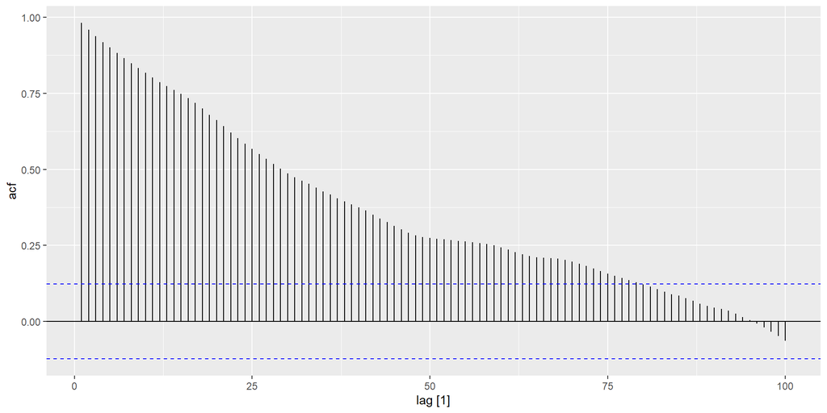

## Which is which?

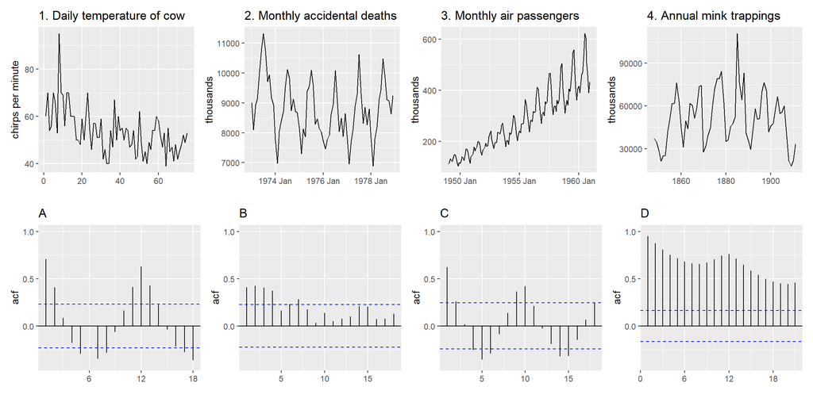

# White noise

## Example: White noise

```r
set.seed(30)
wn <- tsibble(t = 1:50, y = rnorm(50), index = t)
wn |> autoplot(y)
```

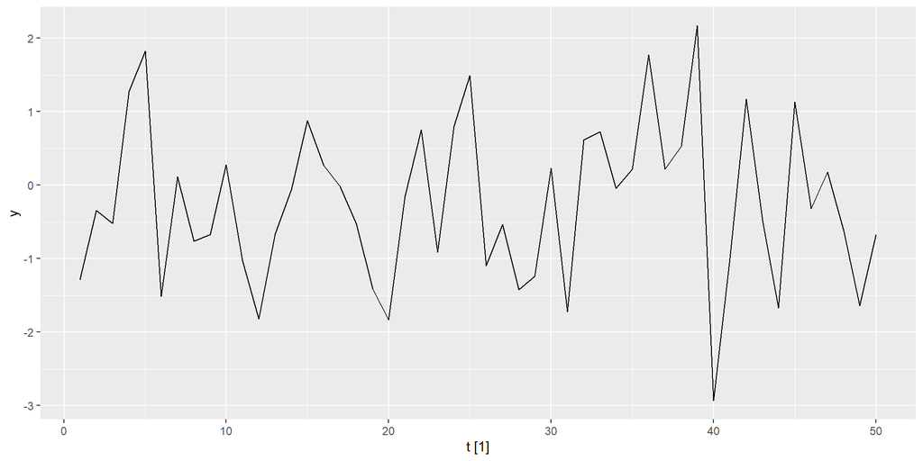

**Note**

White noise data is uncorrelated across time with zero mean and constant variance.

(Technically, we require independence as well.)

## Example: White noise

| $r_{1}$ | $r_{2}$ | $r_{3}$ | $r_{4}$ | $r_{5}$ | $r_{6}$ | $r_{7}$ | $r_{8}$ | $r_{9}$ | $r_{10}$ |
| --- | --- | --- | --- | --- | --- | --- | --- | --- | --- |
| 0.014 | -0.163 | 0.163 | -0.259 | -0.198 | 0.064 | -0.139 | -0.032 | 0.199 | -0.024 |

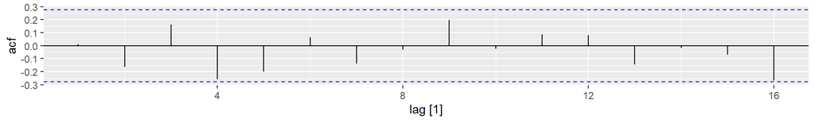

```r
wn |> ACF(y)
```

- Sample autocorrelations for white noise series.
- Expect each autocorrelation to be close to zero.
- Blue lines show 95% critical values.

## Sampling distribution of autocorrelations

Sampling distribution of $r_k$ for white noise data is asymptotically N(0,$1/T$).

## Example: Pigs slaughtered

```r
pigs <- aus_livestock |>
  filter(State == "Victoria", Animal == "Pigs", year(Month) >= 2014)
pigs |> autoplot(Count/1e3) +
  labs(y = "Thousands", title = "Number of pigs slaughtered in Victoria")
```

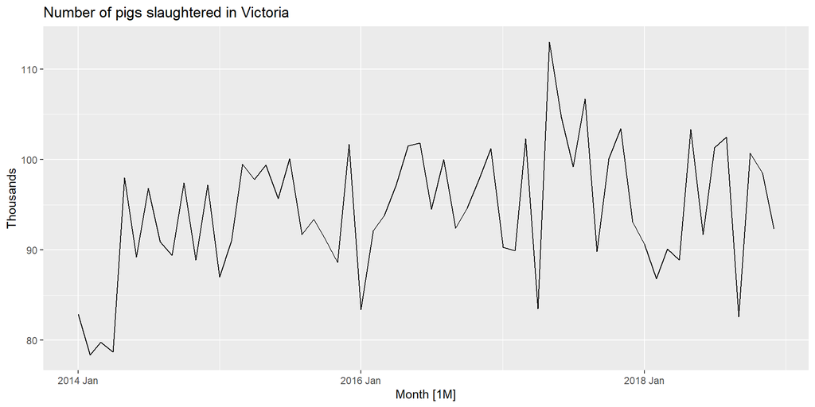

## Example: Pigs slaughtered

```r
pigs |> ACF(Count) |> autoplot()
```

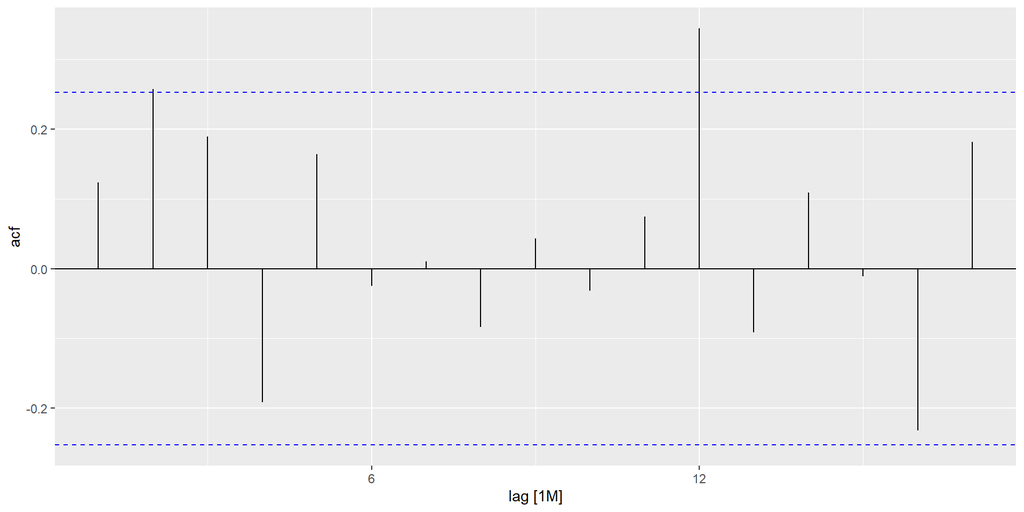

## Example: Pigs slaughtered

Monthly total number of pigs slaughtered in the state of Victoria, Australia, from January 2014 through December 2018 (Source: Australian Bureau of Statistics.)

- Difficult to detect pattern in time plot.
- ACF shows significant autocorrelation for lag 2 and 12.
- Indicate some slight seasonality.

**Important**

These show the series is **not a white noise series**.

## Your turn

You can compute the daily changes in the Google stock price in 2018 using

```r
dgoog <- gafa_stock |>
  filter(Symbol == "GOOG", year(Date) >= 2018) |>
  mutate(diff = difference(Close))
```

Does `diff` look like white noise?